# EEG_Sleep Figures

Stoyo Karamihalev

# Figure 1

## Hypnogram

Representative hypnogram from Group 2, Day 4

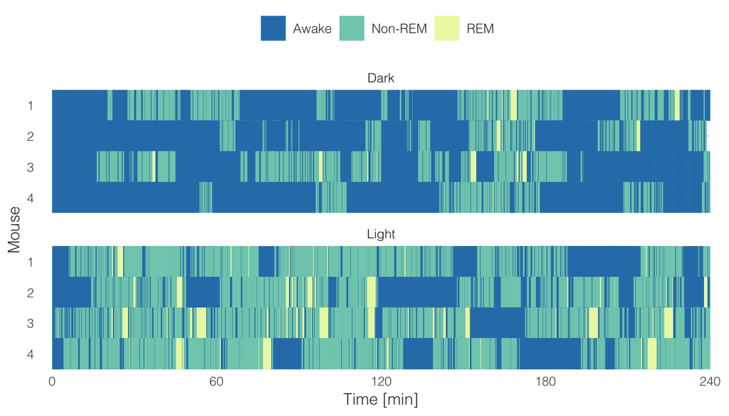

## Figure 1E

Subsetting vigilance data

- remove recordings that failed visual quality inspection (Exclude == F)
- remove recordings from Day 1 (habituation: Day > 1)
- cut time down to 240 min - the quality of recordings drops after 4h due to battery life (eTime <= 240)
- exclude recording 7 (in-between dark/light phase recording)

Compute pairwise correlations

- sleep states are treated as awake or asleep (REM + NREM)
- computes all pairwise correlations (Pearson) between and within groups

### Plot

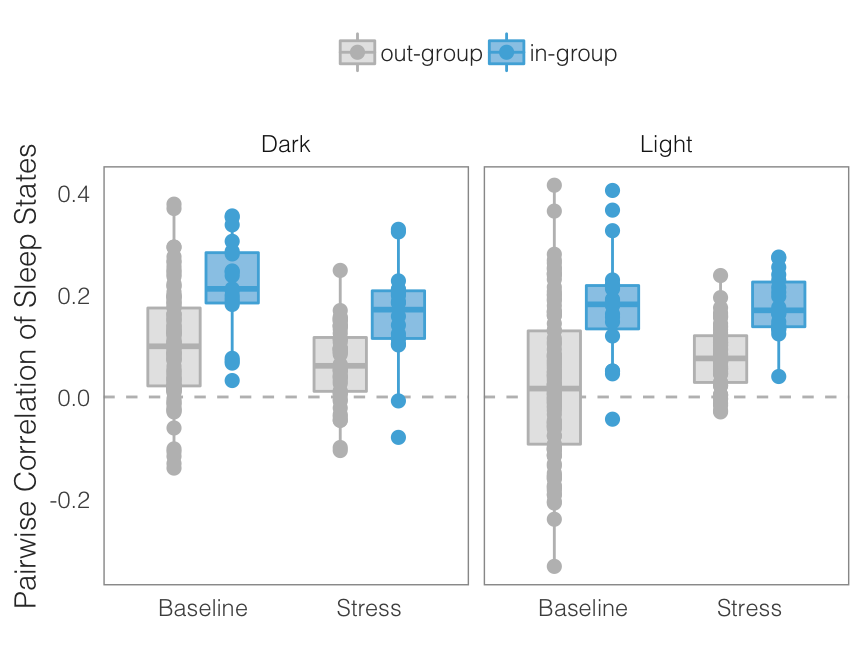

### Stats

Summary:

| GroupType | Light | Stage | n | M | sd |
| --- | --- | --- | --- | --- | --- |
| different | Dark | Baseline | 101 | 0.10219884 | 0.10457032 |
| different | Dark | Stress | 48 | 0.06472817 | 0.07387610 |
| different | Light | Baseline | 101 | 0.02346675 | 0.14656229 |
| different | Light | Stress | 48 | 0.07916251 | 0.06273970 |
| same | Dark | Baseline | 19 | 0.21467001 | 0.09780803 |
| same | Dark | Stress | 18 | 0.15835552 | 0.09928909 |
| same | Light | Baseline | 19 | 0.17953885 | 0.11080984 |
| same | Light | Stress | 18 | 0.18048541 | 0.06115680 |

Unique pairs:

```
## [1] 120
```

#### Shapiro-Wilk test

| GroupType | Light | Stage | statistic | p.value | method |
| --- | --- | --- | --- | --- | --- |
| different | Dark | Baseline | 0.9904843 | 0.6974230 | Shapiro-Wilk normality test |
| different | Dark | Stress | 0.9831548 | 0.7135476 | Shapiro-Wilk normality test |
| different | Light | Baseline | 0.9885653 | 0.5434940 | Shapiro-Wilk normality test |
| different | Light | Stress | 0.9821771 | 0.6713871 | Shapiro-Wilk normality test |
| same | Dark | Baseline | 0.9356130 | 0.2195420 | Shapiro-Wilk normality test |
| same | Dark | Stress | 0.9364803 | 0.2520304 | Shapiro-Wilk normality test |
| same | Light | Baseline | 0.9569417 | 0.5137419 | Shapiro-Wilk normality test |
| same | Light | Stress | 0.9543992 | 0.4981126 | Shapiro-Wilk normality test |

> Normality is not violated in any group

QQ-plots

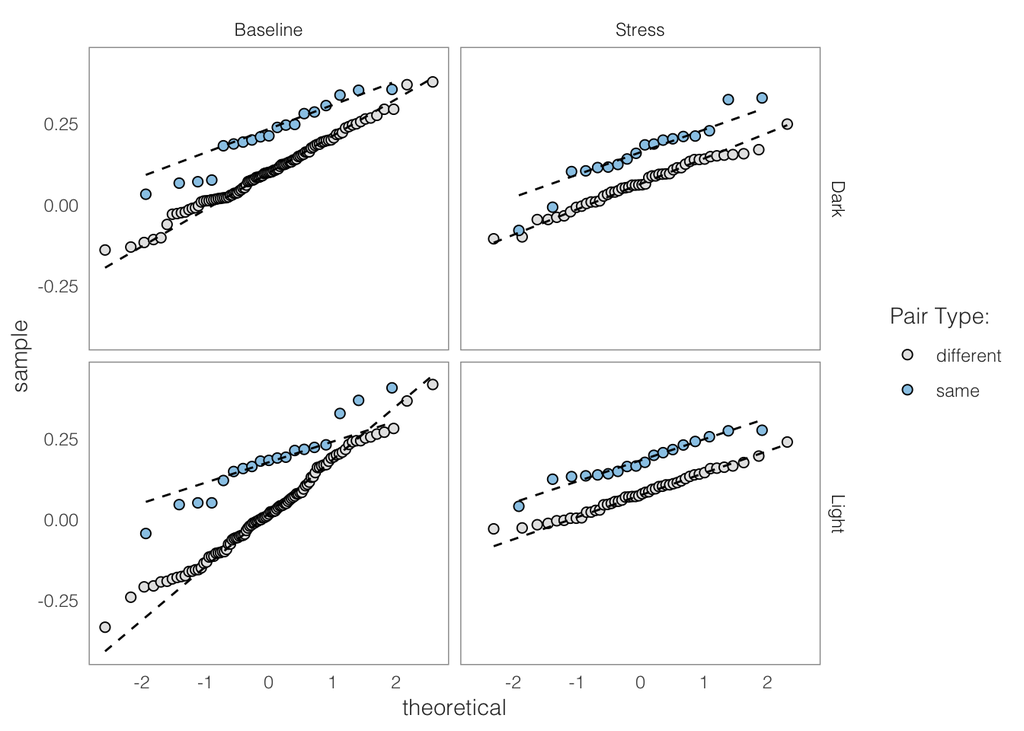

#### Levene’s Test

|  | Df | F value | Pr(>F) |
| --- | --- | --- | --- |
| group | 7 | 7.393341 | 0 |
|  | 364 | NA | NA |

> Groupwise variances are heteroscedastic
- Probably driven by the sample size differences

#### Test

```
## [1] "Settings:  unique SS "
```

| stratum | term | df | R.Sum.Sq | R.Mean.Sq | Iter | Pr.Prob. |
| --- | --- | --- | --- | --- | --- | --- |
| as.factor(pair) | GroupType | 1 | 0.7234812 | 0.7234812 | 5000 | 0.0000000 |
| as.factor(pair) | Stage | 1 | 0.0046275 | 0.0046275 | 51 | 0.9411765 |
| as.factor(pair) | GroupType:Stage | 1 | 0.0238593 | 0.0238593 | 882 | 0.1020408 |
| as.factor(pair) | Residuals | 116 | 1.7747016 | 0.0152992 | NA | NA |
| Within | GroupType | 1 | 0.1109127 | 0.1109127 | 5000 | 0.0010000 |
| Within | Light1 | 1 | 0.1523508 | 0.1523508 | 51 | 1.0000000 |
| Within | GroupType:Light1 | 1 | 0.0254551 | 0.0254551 | 51 | 0.8039216 |
| Within | Stage | 1 | 0.0002219 | 0.0002219 | 51 | 1.0000000 |
| Within | GroupType:Stage | 1 | 0.0008826 | 0.0008826 | 91 | 0.5274725 |
| Within | Light1:Stage | 1 | 0.1517234 | 0.1517234 | 5000 | 0.0018000 |
| Within | GroupType:Light1:Stage | 1 | 0.0046400 | 0.0046400 | 51 | 0.8823529 |
| Within | Residuals | 245 | 2.5119000 | 0.0102527 | NA | NA |

Summary

```
##
## Error: as.factor(pair)
## Component 1 :
##                  Df R Sum Sq R Mean Sq Iter            Pr(Prob)
## GroupType         1  0.72348   0.72348 5000 <0.0000000000000002 ***
## Stage             1  0.00463   0.00463   51              0.9412
## GroupType:Stage   1  0.02386   0.02386  882              0.1020
## Residuals       116  1.77470   0.01530
## ---
## Signif. codes:  0 '***' 0.001 '**' 0.01 '*' 0.05 '.' 0.1 ' ' 1
##
##
## Error: Within
## Component 1 :
##                         Df R Sum Sq R Mean Sq Iter Pr(Prob)
## GroupType                1  0.11091  0.110913 5000   0.0010 ***
## Light1                   1  0.15235  0.152351   51   1.0000
## GroupType:Light1         1  0.02546  0.025455   51   0.8039
## Stage                    1  0.00022  0.000222   51   1.0000
## GroupType:Stage          1  0.00088  0.000883   91   0.5275
## Light1:Stage             1  0.15172  0.151723 5000   0.0018 **
## GroupType:Light1:Stage   1  0.00464  0.004640   51   0.8824
## Residuals              245  2.51190  0.010253
## ---
## Signif. codes:  0 '***' 0.001 '**' 0.01 '*' 0.05 '.' 0.1 ' ' 1
```

## Figure 1F

> “PseudoCausality” over time

Subset data

- only consider bouts with a duration under 40 min

Run pseudo-causality function

Summarize

### Plot

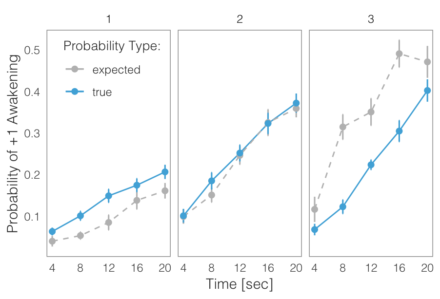

### Stats

Summary:

| GroupType | nMice | timePeriod | n | M | sd |
| --- | --- | --- | --- | --- | --- |
| different | 1 | 1 | 16 | 0.03953500 | 0.05118095 |
| different | 1 | 2 | 16 | 0.05309429 | 0.03479940 |
| different | 1 | 3 | 16 | 0.08466597 | 0.07193322 |
| different | 1 | 4 | 16 | 0.13785452 | 0.08413311 |
| different | 1 | 5 | 16 | 0.16095239 | 0.07499330 |
| different | 2 | 1 | 14 | 0.09900085 | 0.06563588 |
| different | 2 | 2 | 14 | 0.15068641 | 0.06436599 |
| different | 2 | 3 | 14 | 0.24609241 | 0.08076755 |
| different | 2 | 4 | 14 | 0.32516189 | 0.11746618 |
| different | 2 | 5 | 14 | 0.35905617 | 0.07994370 |

[output cut: 20 more lines]

```
## [1] 16
```

#### Shapiro-Wilk test

| GroupType | nMice | timePeriod | statistic | p.value | method |
| --- | --- | --- | --- | --- | --- |
| different | 1 | 1 | 0.7770526 | 0.001371876 | Shapiro-Wilk normality test |
| different | 2 | 1 | 0.8827619 | 0.063635456 | Shapiro-Wilk normality test |
| different | 1 | 2 | 0.9401988 | 0.351455441 | Shapiro-Wilk normality test |
| different | 2 | 2 | 0.9291484 | 0.296855171 | Shapiro-Wilk normality test |
| different | 1 | 3 | 0.9110513 | 0.121002879 | Shapiro-Wilk normality test |
| different | 2 | 3 | 0.9596460 | 0.717258529 | Shapiro-Wilk normality test |
| different | 1 | 4 | 0.9084058 | 0.109685878 | Shapiro-Wilk normality test |
| different | 2 | 4 | 0.8925324 | 0.087925779 | Shapiro-Wilk normality test |
| different | 1 | 5 | 0.9739513 | 0.897827046 | Shapiro-Wilk normality test |
| different | 2 | 5 | 0.9247641 | 0.257306533 | Shapiro-Wilk normality test |

[output cut: 20 more lines]

> Normality is violated in nMice == 1

#### Levene’s Test

|  | Df | F value | Pr(>F) |
| --- | --- | --- | --- |
| group | 29 | 1.695526 | 0.0155931 |
|  | 350 | NA | NA |

> Groupwise variances are heteroscedastic

> Mann-Whitney-Wilcoxon Test for time 1

Awake mice: 1

| statistic | p.value | method | alternative |
| --- | --- | --- | --- |
| 73 | 0.0388457 | Wilcoxon rank sum test with continuity correction | two.sided |

Awake mice: 3

| statistic | p.value | method | alternative |
| --- | --- | --- | --- |
| 45 | 0.1879591 | Wilcoxon rank sum test with continuity correction | two.sided |

> lmPerm

Repeated-measures:

```
## [1] "Settings:  unique SS : numeric variables centered"
```

| stratum | term | df | R.Sum.Sq | R.Mean.Sq | Iter | Pr.Prob. |
| --- | --- | --- | --- | --- | --- | --- |
| as.factor(MouseNumber) | nMice | 1 | 0.2569083 | 0.2569083 | 5000 | 0.0014 |
| as.factor(MouseNumber) | Residuals | 14 | 0.2337892 | 0.0166992 | NA | NA |
| Within | GroupType1 | 1 | 0.0015733 | 0.0015733 | 51 | 1.0000 |
| Within | nMice | 1 | 1.5497744 | 1.5497744 | 5000 | 0.0000 |
| Within | GroupType1:nMice | 1 | 0.3331050 | 0.3331050 | 5000 | 0.0000 |
| Within | as.factor(timePeriod) | 4 | 2.5890506 | 0.6472627 | 5000 | 0.0000 |
| Within | Residuals | 357 | 2.2431089 | 0.0062832 | NA | NA |

```
##
## Error: as.factor(MouseNumber)
## Component 1 :
##           Df R Sum Sq R Mean Sq Iter Pr(Prob)
## nMice      1  0.25691  0.256908 5000   0.0014 **
## Residuals 14  0.23379  0.016699
## ---
## Signif. codes:  0 '***' 0.001 '**' 0.01 '*' 0.05 '.' 0.1 ' ' 1
##
##
## Error: Within
## Component 1 :
##                        Df R Sum Sq R Mean Sq Iter            Pr(Prob)
## GroupType1              1  0.00157   0.00157   51                   1
## nMice                   1  1.54977   1.54977 5000 <0.0000000000000002 ***
## GroupType1:nMice        1  0.33310   0.33310 5000 <0.0000000000000002 ***
## as.factor(timePeriod)   4  2.58905   0.64726 5000 <0.0000000000000002 ***
## Residuals             357  2.24311   0.00628
## ---
## Signif. codes:  0 '***' 0.001 '**' 0.01 '*' 0.05 '.' 0.1 ' ' 1
```

Awake mice: 1

```
## [1] "Settings:  unique SS "
```

| stratum | term | df | R.Sum.Sq | R.Mean.Sq | Iter | Pr.Prob. |
| --- | --- | --- | --- | --- | --- | --- |
| as.factor(MouseNumber) | Residuals | 15 | 0.1060661 | 0.0070711 | NA | NA |
| Within | GroupType1 | 1 | 0.0755079 | 0.0755079 | 5000 | 0 |
| Within | as.factor(timePeriod) | 4 | 0.3809504 | 0.0952376 | 5000 | 0 |
| Within | Residuals | 139 | 0.4687782 | 0.0033725 | NA | NA |

Summary

```
##
## Error: as.factor(MouseNumber)
## Component 1 :
##           Df R Sum Sq R Mean Sq
## Residuals 15  0.10607 0.0070711
##
##
## Error: Within
## Component 1 :
##                        Df R Sum Sq R Mean Sq Iter              Pr(Prob)
## GroupType1              1  0.07551  0.075508 5000 < 0.00000000000000022
## as.factor(timePeriod)   4  0.38095  0.095238 5000 < 0.00000000000000022
## Residuals             139  0.46878  0.003373
##
## GroupType1            ***
## as.factor(timePeriod) ***
## Residuals
## ---
## Signif. codes:  0 '***' 0.001 '**' 0.01 '*' 0.05 '.' 0.1 ' ' 1
```

Awake mice: 2

```
## [1] "Settings:  unique SS "
```

| stratum | term | df | R.Sum.Sq | R.Mean.Sq | Iter | Pr.Prob. |
| --- | --- | --- | --- | --- | --- | --- |
| as.factor(MouseNumber) | Residuals | 13 | 0.2629157 | 0.0202243 | NA | NA |
| Within | GroupType1 | 1 | 0.0038501 | 0.0038501 | 146 | 0.4109589 |
| Within | as.factor(timePeriod) | 4 | 1.3369610 | 0.3342402 | 5000 | 0.0000000 |
| Within | Residuals | 121 | 0.6011011 | 0.0049678 | NA | NA |

Summary

```
##
## Error: as.factor(MouseNumber)
## Component 1 :
##           Df R Sum Sq R Mean Sq
## Residuals 13  0.26292  0.020224
##
##
## Error: Within
## Component 1 :
##                        Df R Sum Sq R Mean Sq Iter            Pr(Prob)
## GroupType1              1  0.00385   0.00385  146               0.411
## as.factor(timePeriod)   4  1.33696   0.33424 5000 <0.0000000000000002 ***
## Residuals             121  0.60110   0.00497
## ---
## Signif. codes:  0 '***' 0.001 '**' 0.01 '*' 0.05 '.' 0.1 ' ' 1
```

Awake mice: 3

```
## [1] "Settings:  unique SS "
```

| stratum | term | df | R.Sum.Sq | R.Mean.Sq | Iter | Pr.Prob. |
| --- | --- | --- | --- | --- | --- | --- |
| as.factor(MouseNumber) | Residuals | 7 | 0.1136644 | 0.0162378 | NA | NA |
| Within | GroupType1 | 1 | 0.3104018 | 0.3104018 | 5000 | 0 |
| Within | as.factor(timePeriod) | 4 | 1.2393094 | 0.3098273 | 5000 | 0 |
| Within | Residuals | 67 | 0.3690574 | 0.0055083 | NA | NA |

Summary

```
##
## Error: as.factor(MouseNumber)
## Component 1 :
##           Df R Sum Sq R Mean Sq
## Residuals  7  0.11366  0.016238
##
##
## Error: Within
## Component 1 :
##                       Df R Sum Sq R Mean Sq Iter              Pr(Prob)
## GroupType1             1  0.31040  0.310402 5000 < 0.00000000000000022 ***
## as.factor(timePeriod)  4  1.23931  0.309827 5000 < 0.00000000000000022 ***
## Residuals             67  0.36906  0.005508
## ---
## Signif. codes:  0 '***' 0.001 '**' 0.01 '*' 0.05 '.' 0.1 ' ' 1
```

# Figure 2

## Figure 2A

> Sleep Types [%] Stacked

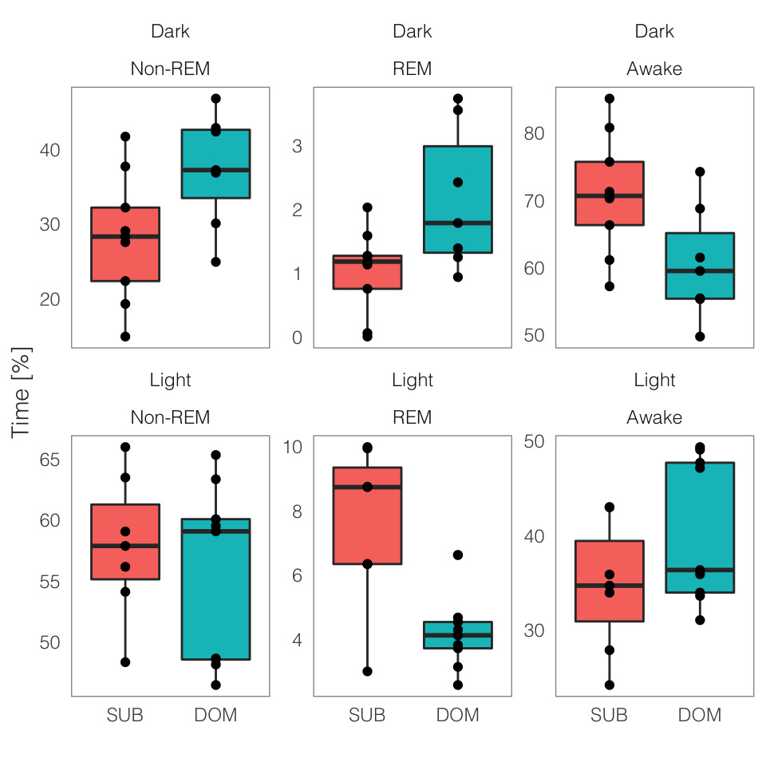

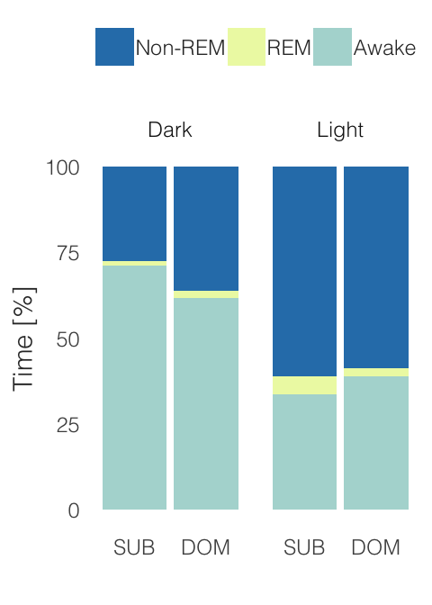

Number of individuals:

```
## [1] 18
```

## Figure 2B

> REM [%] x Rank - Baseline

### Plot

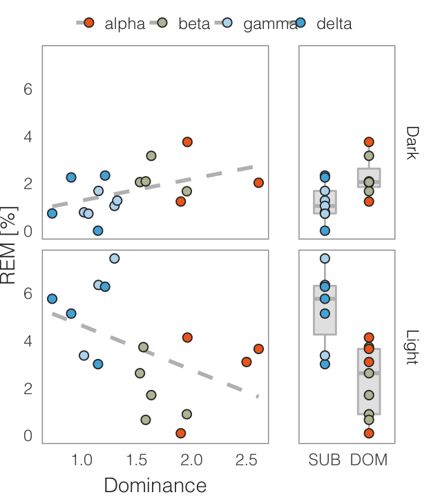

### Stats

Number of mice:

```
## [1] 18
```

Summary:

| Light | RankBinary | n | M | sd |
| --- | --- | --- | --- | --- |
| Dark | SUB | 9 | 1.028669 | 0.6648559 |
| Dark | DOM | 7 | 2.153088 | 1.1245723 |
| Light | SUB | 7 | 7.576193 | 2.5194258 |
| Light | DOM | 9 | 4.160035 | 1.1378917 |

#### Shapiro-Wilk test

| Light | RankBinary | statistic | p.value | method |
| --- | --- | --- | --- | --- |
| Dark | DOM | 0.8865570 | 0.2571808 | Shapiro-Wilk normality test |
| Dark | SUB | 0.9217058 | 0.4065498 | Shapiro-Wilk normality test |
| Light | DOM | 0.9212435 | 0.4026342 | Shapiro-Wilk normality test |
| Light | SUB | 0.8777403 | 0.2166056 | Shapiro-Wilk normality test |

> Normality is not violated in any group

#### Levene’s Test

|  | Df | F value | Pr(>F) |
| --- | --- | --- | --- |
| group | 3 | 2.294382 | 0.0995947 |
|  | 28 | NA | NA |

> Groupwise variances are not heteroscedastic (although a trend exists)

#### Continuous predictor

|  | numDF | denDF | F-value | p-value |
| --- | --- | --- | --- | --- |
| (Intercept) | 1 | 12 | 120.94931923 | 0.0000001269964 |
| CumNormDavidScore | 1 | 12 | 0.06385059 | 0.8047867899737 |
| Light | 1 | 12 | 46.74103309 | 0.0000180591946 |
| CumNormDavidScore:Light | 1 | 12 | 6.00844418 | 0.0305253991049 |

#### Binary predictor

|  | numDF | denDF | F-value | p-value |
| --- | --- | --- | --- | --- |
| (Intercept) | 1 | 12 | 155.3207264 | 0.0000000316878 |
| RankBinary | 1 | 12 | 0.7201084 | 0.4127163369471 |
| Light | 1 | 12 | 89.9005603 | 0.0000006345816 |
| RankBinary:Light | 1 | 12 | 24.9716064 | 0.0003107858880 |

## Figure 2C

> SWA x Rank - Baseline

Load EEG FFT23:

```
## [1] "FFT  files: 243"
```

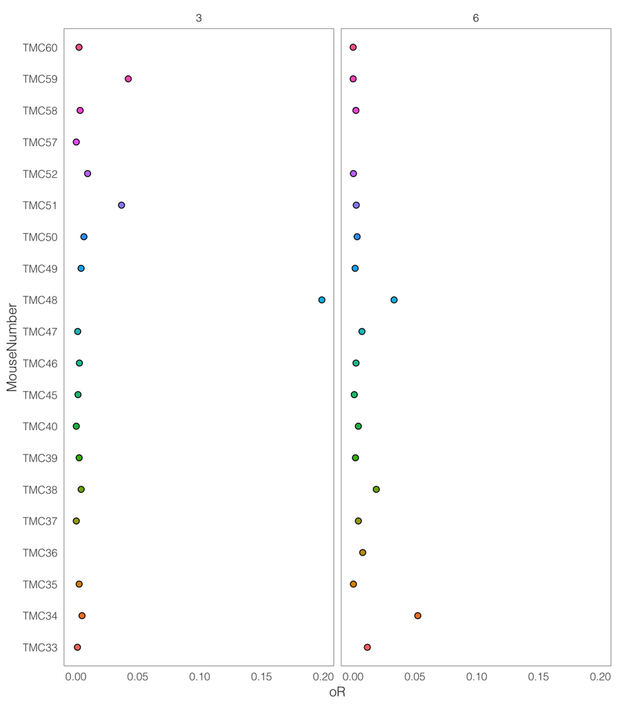

```
## [1] 0.8943566
```

### Plot

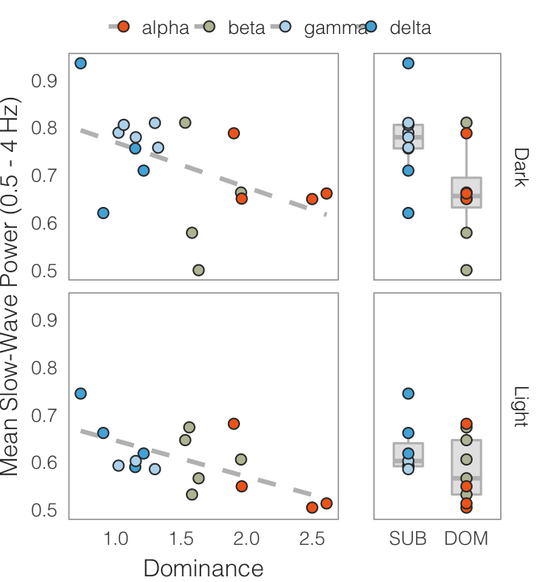

### Stats

Number of mice:

```
## [1] 18
```

Summary:

| Light | RankBinary | n | M | sd |
| --- | --- | --- | --- | --- |
| Dark | SUB | 9 | 0.8144436 | 0.1627451 |
| Dark | DOM | 8 | 0.7088237 | 0.1154653 |
| Light | SUB | 7 | 0.6348228 | 0.1182415 |
| Light | DOM | 9 | 0.5729449 | 0.1142142 |

#### Shapiro-Wilk test

| Light | RankBinary | statistic | p.value | method |
| --- | --- | --- | --- | --- |
| Dark | SUB | 0.9753684 | 0.9363442 | Shapiro-Wilk normality test |
| Dark | DOM | 0.9813844 | 0.9694281 | Shapiro-Wilk normality test |
| Light | SUB | 0.9301075 | 0.5518142 | Shapiro-Wilk normality test |
| Light | DOM | 0.9110561 | 0.3233363 | Shapiro-Wilk normality test |

> Normality is not violated in any group

#### Levene’s Test

|  | Df | F value | Pr(>F) |
| --- | --- | --- | --- |
| group | 3 | 0.4157312 | 0.7429968 |
|  | 29 | NA | NA |

> Groupwise variances are not heteroscedastic

#### Continuous predictor

|  | numDF | denDF | F-value | p-value |
| --- | --- | --- | --- | --- |
| (Intercept) | 1 | 13 | 257.83818039 | 0.0000000005941201 |
| CumNormDavidScore | 1 | 12 | 6.80836641 | 0.0228317174467185 |
| Light | 1 | 13 | 46.03278768 | 0.0000129209830334 |
| CumNormDavidScore:Light | 1 | 13 | 0.08412041 | 0.7763639210677711 |

#### Binary predictor

|  | numDF | denDF | F-value | p-value |
| --- | --- | --- | --- | --- |
| (Intercept) | 1 | 13 | 251.238374 | 0.0000000006978322 |
| RankBinary | 1 | 12 | 5.575709 | 0.0359665879473867 |
| Light | 1 | 13 | 48.193658 | 0.0000101858166757 |
| RankBinary:Light | 1 | 13 | 1.536560 | 0.2370418888741808 |

### Bonus

#### Min SWA x Rank

- Why is the minimum slow-wave activity that much lower / close to zero in subordinates during the light phase?

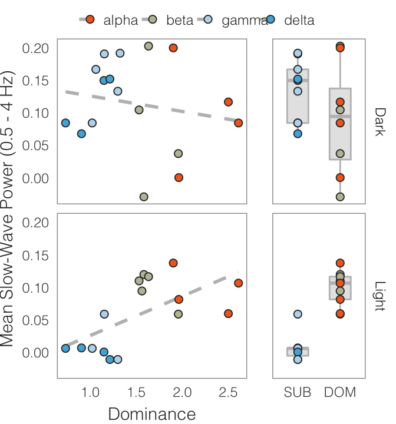

## Figure 2D

> Fragmentation x Rank - baseline

### Plot

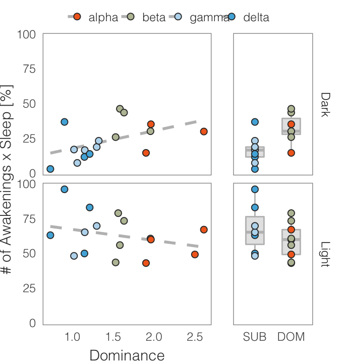

### Stats

Number of mice:

```
## [1] 18
```

Summary:

| Light | RankBinary | n | M | sd |
| --- | --- | --- | --- | --- |
| Dark | SUB | 9 | 23.33879 | 11.10197 |
| Dark | DOM | 7 | 40.35517 | 16.61170 |
| Light | SUB | 7 | 60.39107 | 21.26328 |
| Light | DOM | 9 | 52.91086 | 12.54785 |

#### Shapiro-Wilk test

| Light | RankBinary | statistic | p.value | method |
| --- | --- | --- | --- | --- |
| Dark | DOM | 0.9615060 | 0.8315469 | Shapiro-Wilk normality test |
| Dark | SUB | 0.8807336 | 0.1598333 | Shapiro-Wilk normality test |
| Light | DOM | 0.8982918 | 0.2422643 | Shapiro-Wilk normality test |
| Light | SUB | 0.9277426 | 0.5318682 | Shapiro-Wilk normality test |

> Normality is not violated in any group

#### Levene’s Test

|  | Df | F value | Pr(>F) |
| --- | --- | --- | --- |
| group | 3 | 0.9178924 | 0.4449394 |
|  | 28 | NA | NA |

#### Continuous predictor

|  | numDF | denDF | F-value | p-value |
| --- | --- | --- | --- | --- |
| (Intercept) | 1 | 12 | 200.8052779 | 0.000000007434838 |
| CumNormDavidScore | 1 | 12 | 0.6139359 | 0.448498938473271 |
| Light | 1 | 12 | 23.6007238 | 0.000392841388069 |
| CumNormDavidScore:Light | 1 | 12 | 3.9332089 | 0.070702430152545 |

#### Binary predictor

|  | numDF | denDF | F-value | p-value |
| --- | --- | --- | --- | --- |
| (Intercept) | 1 | 12 | 197.049951 | 0.000000008276829 |
| RankBinary | 1 | 12 | 2.316572 | 0.153908354902700 |
| Light | 1 | 12 | 28.242237 | 0.000183985565618 |
| RankBinary:Light | 1 | 12 | 7.573625 | 0.017536465390427 |

Posthoc - Light:

|  | numDF | denDF | F-value | p-value |
| --- | --- | --- | --- | --- |
| (Intercept) | 1 | 10 | 177.9988663 | 0.0000001071963 |
| RankBinary | 1 | 10 | 0.7764774 | 0.3989045937952 |

Posthoc - Dark:

|  | numDF | denDF | F-value | p-value |
| --- | --- | --- | --- | --- |
| (Intercept) | 1 | 10 | 51.681062 | 0.00002964627 |
| RankBinary | 1 | 10 | 7.368697 | 0.02176355101 |

## Figure 2E

> REM Duration x Rank x Stage

### Plot

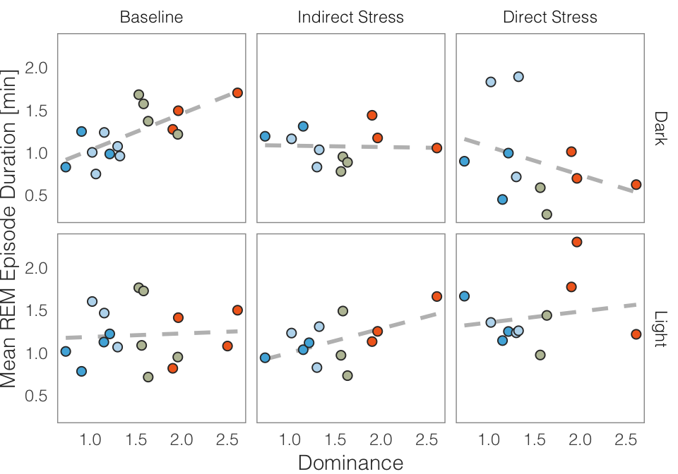

Boxplots

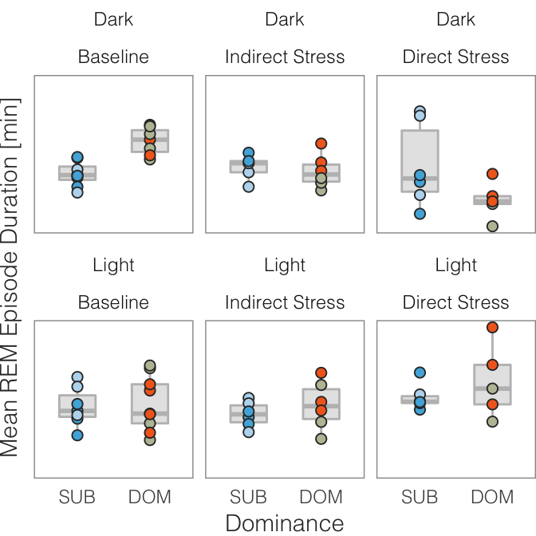

### Stats

Number of mice:

```
## [1] 18
```

Summary:

| Light | RankBinary | n | M | sd |
| --- | --- | --- | --- | --- |
| Dark | SUB | 19 | 0.9741233 | 0.4923754 |
| Dark | DOM | 18 | 1.0353508 | 0.2694369 |
| Light | SUB | 19 | 1.0376057 | 0.2525323 |
| Light | DOM | 20 | 1.1835740 | 0.4449562 |

#### Shapiro-Wilk test

| Light | Stage | RankBinary | statistic | p.value | method |
| --- | --- | --- | --- | --- | --- |
| Dark | Baseline | DOM | 0.8982760 | 0.3206694 | Shapiro-Wilk normality test |
| Dark | Baseline | SUB | 0.8839884 | 0.2055201 | Shapiro-Wilk normality test |
| Light | Baseline | DOM | 0.9687799 | 0.8840978 | Shapiro-Wilk normality test |
| Light | Baseline | SUB | 0.8970531 | 0.3135086 | Shapiro-Wilk normality test |
| Dark | Indirect Stress | DOM | 0.9712190 | 0.9005206 | Shapiro-Wilk normality test |
| Dark | Indirect Stress | SUB | 0.8339408 | 0.1488575 | Shapiro-Wilk normality test |
| Light | Indirect Stress | DOM | 0.9898726 | 0.9888612 | Shapiro-Wilk normality test |
| Light | Indirect Stress | SUB | 0.9575173 | 0.8004168 | Shapiro-Wilk normality test |
| Dark | Direct Stress | DOM | 0.9169113 | 0.5102133 | Shapiro-Wilk normality test |
| Dark | Direct Stress | SUB | 0.9223612 | 0.5225276 | Shapiro-Wilk normality test |

[output cut: 2 more lines]

> Normality is not violated in any group

#### Levene’s Test

|  | Df | F value | Pr(>F) |
| --- | --- | --- | --- |
| group | 11 | 1.943249 | 0.0497985 |
|  | 64 | NA | NA |

#### Continuous predictor

|  | numDF | denDF | F-value | p-value |
| --- | --- | --- | --- | --- |
| (Intercept) | 1 | 48 | 319.41274905 | 0.00000000 |
| CumNormDavidScore | 1 | 12 | 1.57918131 | 0.23279025 |
| Stage | 2 | 48 | 0.33747708 | 0.71524770 |
| Light | 1 | 48 | 2.10849223 | 0.15298917 |
| CumNormDavidScore:Stage | 2 | 48 | 1.99879532 | 0.14661972 |
| CumNormDavidScore:Light | 1 | 48 | 0.03063406 | 0.86179551 |
| Stage:Light | 2 | 48 | 0.41252056 | 0.66430401 |
| CumNormDavidScore:Stage:Light | 2 | 48 | 3.87313740 | 0.02758095 |

##### Dark Phase

|  | numDF | denDF | F-value | p-value |
| --- | --- | --- | --- | --- |
| (Intercept) | 1 | 16 | 270.2428030 | 0.00000000001919798 |
| CumNormDavidScore | 1 | 11 | 0.8814453 | 0.36796423630734421 |
| Stage | 2 | 16 | 0.6876141 | 0.51702999230609570 |
| CumNormDavidScore:Stage | 2 | 16 | 4.6704076 | 0.02525778183809513 |

##### Light Phase

|  | numDF | denDF | F-value | p-value |
| --- | --- | --- | --- | --- |
| (Intercept) | 1 | 18 | 241.93191286 | 0.000000000007014167 |
| CumNormDavidScore | 1 | 11 | 0.81544648 | 0.385862799277320367 |
| Stage | 2 | 18 | 0.08410096 | 0.919697520728659623 |
| CumNormDavidScore:Stage | 2 | 18 | 0.36802032 | 0.697191638139921910 |

#### Binary predictor

|  | numDF | denDF | F-value | p-value |
| --- | --- | --- | --- | --- |
| (Intercept) | 1 | 48 | 328.7288296 | 0.00000000 |
| RankBinary | 1 | 12 | 1.4219676 | 0.25612672 |
| Stage | 2 | 48 | 0.3363724 | 0.71602727 |
| Light | 1 | 48 | 2.1873999 | 0.14567717 |
| RankBinary:Stage | 2 | 48 | 1.7194502 | 0.19001569 |
| RankBinary:Light | 1 | 48 | 0.3831731 | 0.53883684 |
| Stage:Light | 2 | 48 | 0.3953536 | 0.67561451 |
| RankBinary:Stage:Light | 2 | 48 | 4.8869351 | 0.01170131 |

##### Dark Phase

|  | numDF | denDF | F-value | p-value |
| --- | --- | --- | --- | --- |
| (Intercept) | 1 | 16 | 279.0666573 | 0.0000000000150463 |
| RankBinary | 1 | 11 | 0.2955324 | 0.5975418120985485 |
| Stage | 2 | 16 | 0.7491690 | 0.4886360064019158 |
| RankBinary:Stage | 2 | 16 | 6.0324901 | 0.0111594278976824 |

##### Light Phase

|  | numDF | denDF | F-value | p-value |
| --- | --- | --- | --- | --- |
| (Intercept) | 1 | 18 | 230.34335319 | 0.00000000001059042 |
| RankBinary | 1 | 11 | 1.02078932 | 0.33403997963145082 |
| Stage | 2 | 18 | 0.07047257 | 0.93220913786735293 |
| RankBinary:Stage | 2 | 18 | 0.43660907 | 0.65288833277909530 |